# WDFW Fish Passage Inventory Explore

Connor Lewis-Smith

12/27/2021

## Getting to Know the WDFW Fish Passage Inventory Data

In this markdown, we introduce and explore the WDFW fish passage data. More information from the WDFW can be found at this link: (https://wdfw.wa.gov/species-habitats/habitat-recovery/fish-passage/assessment). Since the data is being updated by WDFW on a rolling basis, this document should be ran after re-downloading the zip file to display the most up to date information. This process does take time to download, so only re-pull the zip when necessary. The “if” statement below is used to prevent re-downloading the zip file for every run.

The first chunk of code was primarily written by Braeden and copied into this markdown by Connor, the following chunks where used to explore the data set during Connor’s RAship in the Fall of 2021.

Below provides an introduction to the Fish Passage Inventory data set broadly. This includes displaying the Coordinate Reference System, along with the variable names, and some basic summary statistics.

```r
# ____ WDFW inventory ----
if(!file.exists(here("data/culv_inventories/WdfwFishPassage.zip"))){
  download.file(
    "https://fortress.wa.gov/dfw/public/PublicDownload/habitat/FishPassage/WdfwFishPassage.zip",
    here("data/culv_inventories/WdfwFishPassage.zip")
  )
  unzip(
    here("data/culv_inventories/WdfwFishPassage.zip"),
    exdir = here("data/culv_inventories/WdfwFishPassage")
  )
}

st_layers(here("data/culv_inventories/WdfwFishPassage/WdfwFishPassage.gdb"))
```

```
## Driver: OpenFileGDB
## Available layers:
##             layer_name geometry_type features fields
## 1 WDFW_FishPassageSite         Point    56711     31
## 2           ImageLinks            NA    53865      2
```

```r
sf_allculv_wdfw <- st_read(here("data/culv_inventories/WdfwFishPassage/WdfwFishPassage.gdb"), layer = "WDFW_FishPassageSite")
# Check projection
st_crs(sf_allculv_wdfw)
```

```
## Coordinate Reference System:
##   User input: NAD83(HARN) / Washington South
##   wkt:
## PROJCRS["NAD83(HARN) / Washington South",
##     BASEGEOGCRS["NAD83(HARN)",
##         DATUM["NAD83 (High Accuracy Reference Network)",
##             ELLIPSOID["GRS 1980",6378137,298.257222101,
##                 LENGTHUNIT["metre",1]]],
##         PRIMEM["Greenwich",0,
##             ANGLEUNIT["degree",0.0174532925199433]],
##         ID["EPSG",4152]],
##     CONVERSION["SPCS83 Washington South zone (meters)",
##         METHOD["Lambert Conic Conformal (2SP)",
##             ID["EPSG",9802]],
##         PARAMETER["Latitude of false origin",45.3333333333333,
##             ANGLEUNIT["degree",0.0174532925199433],
##             ID["EPSG",8821]],
##         PARAMETER["Longitude of false origin",-120.5,
##             ANGLEUNIT["degree",0.0174532925199433],
##             ID["EPSG",8822]],
##         PARAMETER["Latitude of 1st standard parallel",47.3333333333333,
##             ANGLEUNIT["degree",0.0174532925199433],
##             ID["EPSG",8823]],
##         PARAMETER["Latitude of 2nd standard parallel",45.8333333333333,
##             ANGLEUNIT["degree",0.0174532925199433],
##             ID["EPSG",8824]],
##         PARAMETER["Easting at false origin",500000,
##             LENGTHUNIT["metre",1],
##             ID["EPSG",8826]],
##         PARAMETER["Northing at false origin",0,
##             LENGTHUNIT["metre",1],
##             ID["EPSG",8827]]],
##     CS[Cartesian,2],
##         AXIS["easting (X)",east,
##             ORDER[1],
##             LENGTHUNIT["metre",1]],
##         AXIS["northing (Y)",north,
##             ORDER[2],
##             LENGTHUNIT["metre",1]],
##     USAGE[
##         SCOPE["Engineering survey, topographic mapping."],
##         AREA["United States (USA) - Washington - counties of Adams; Asotin; Benton; Clark; Columbia; Cowlitz; Franklin; Garfield; Grant south of approximately 47°30'N; Grays Harbor; Kittitas; Klickitat; Lewis; Mason; Pacific; Pierce; Skamania; Thurston; Wahkiakum; Walla Walla; Whitman; Yakima."],
##         BBOX[45.54,-124.4,47.61,-116.91]],
##     ID["EPSG",2856]]
```

```r
# Check variable names
names(sf_allculv_wdfw)
```

```
##  [1] "SiteRecordID"                 "SiteId"
##  [3] "SiteLatitude"                 "SiteLongitude"
##  [5] "FishPassageFeatureTypeCode"   "FeatureType"
##  [7] "StreamName"                   "TributaryToName"
##  [9] "FishUseCode"                  "FishUseCriteriaCode"
## [11] "RoadName"                     "RoadMilePostMeasurement"
## [13] "FishPassageBarrierStatusCode" "FishPassageBarrierReasonCode"
## [15] "PercentFishPassableCode"      "SignificantReachCode"
## [17] "OwnerTypeCode"                "DataSource"
## [19] "SurveyDate"                   "LinealGainMeasurement"
## [21] "PriorityIndexTotalQuantity"   "PotentialSpecies"
## [23] "BarrierCorrectionTypeCode"    "BarrierCorrectionYearsText"
## [25] "CaseAreaFlag"                 "FormLinkURL"
## [27] "WRIANumber"                   "CountyName"
## [29] "IncorporatedCityName"         "HUC12Name"
## [31] "ProjectName"                  "Shape"
```

```r
# Repair names
sf_allculv_wdfw <- sf_allculv_wdfw %>% clean_names()
names(sf_allculv_wdfw)
```

```
##  [1] "site_record_id"                   "site_id"
##  [3] "site_latitude"                    "site_longitude"
##  [5] "fish_passage_feature_type_code"   "feature_type"
##  [7] "stream_name"                      "tributary_to_name"
##  [9] "fish_use_code"                    "fish_use_criteria_code"
## [11] "road_name"                        "road_mile_post_measurement"
## [13] "fish_passage_barrier_status_code" "fish_passage_barrier_reason_code"
## [15] "percent_fish_passable_code"       "significant_reach_code"
## [17] "owner_type_code"                  "data_source"
## [19] "survey_date"                      "lineal_gain_measurement"
## [21] "priority_index_total_quantity"    "potential_species"
## [23] "barrier_correction_type_code"     "barrier_correction_years_text"
## [25] "case_area_flag"                   "form_link_url"
## [27] "wria_number"                      "county_name"
## [29] "incorporated_city_name"           "huc12name"
## [31] "project_name"                     "Shape"
```

```r
# Lots of variables look like they're codes, will need to find codebook
# Currently building custom codebook using https://geodataservices.wdfw.wa.gov/hp/fishpassage/index.html

# Check some key variables
sf_allculv_wdfw %>% tabyl(feature_type)
```

```
##            feature_typeShape     n      percent valid_percent
##                      Culvert 36968 6.518665e-01  6.692373e-01
##           Culvert, Diversion    25 4.408316e-04  4.525788e-04
##             Culvert, Fishway   137 2.415757e-03  2.480132e-03
##                          Dam  1413 2.491580e-02  2.557975e-02
##               Dam, Diversion   344 6.065843e-03  6.227484e-03
##                 Dam, Fishway   118 2.080725e-03  2.136172e-03
##      Dam, Fishway, Diversion    30 5.289979e-04  5.430946e-04
##                    Diversion  1054 1.858546e-02  1.908072e-02
##           Diversion, Culvert     2 3.526653e-05  3.620630e-05
##               Diversion, Dam    47 8.287634e-04  8.508481e-04
##  Diversion, Non Culvert Xing     1 1.763326e-05  1.810315e-05
##             Fishway, Culvert   443 7.811536e-03  8.019696e-03
##                 Fishway, Dam    40 7.053305e-04  7.241261e-04
##      Fishway, Dam, Diversion    19 3.350320e-04  3.439599e-04
##      Fishway, Diversion, Dam     1 1.763326e-05  1.810315e-05
##     Fishway, Natural Barrier    52 9.169297e-04  9.413639e-04
##    Fishway, Non Culvert Xing    24 4.231983e-04  4.344756e-04
##               Fishway, Other    14 2.468657e-04  2.534441e-04
##              Natural Barrier  7201 1.269771e-01  1.303608e-01
##     Natural Barrier, Fishway    47 8.287634e-04  8.508481e-04
##             Non Culvert Xing  6724 1.185661e-01  1.217256e-01
##  Non Culvert Xing, Diversion     6 1.057996e-04  1.086189e-04
##    Non Culvert Xing, Fishway     2 3.526653e-05  3.620630e-05
##                        Other   512 9.028231e-03  9.268814e-03
##             Other, Diversion     9 1.586994e-04  1.629284e-04
##               Other, Fishway     5 8.816632e-05  9.051576e-05
##    Other, Fishway, Diversion     1 1.763326e-05  1.810315e-05
##                         <NA>  1472 2.595616e-02            NA
```

```r
# Lots of culverts! Over 35k!
summary(sf_allculv_wdfw$lineal_gain_measurement)
```

```
##     Min.  1st Qu.   Median     Mean  3rd Qu.     Max.     NA's
##      0.0    328.5    988.0   4066.8   2897.0 231853.0    47588
```

```r
# Big distribution of lineal gain, though unclear how this is calculated; appears to be in meters
sf_allculv_wdfw %>% filter(str_detect(feature_type, "Culvert")) %>% tabyl(fish_passage_feature_type_code) # Codes needed (1 = culvert, 2 = non-culvert xing, 3 = dam, 4 = other, 5 = natural barrier)
```

```
##  fish_passage_feature_type_codeShape     n   percent
##                                    1 37575 0.8475819
##                                    2  6757 0.1524181
```

```r
sf_allculv_wdfw %>% filter(str_detect(feature_type, "Culvert")) %>% tabyl(fish_passage_barrier_status_code) # Codes needed (0 = NA, 10 = Barrier, 20 = Not a barrier, 99 = Unknown)
```

```
##  fish_passage_barrier_status_codeShape     n      percent valid_percent
##                                      0  8395 1.893666e-01     0.1893751
##                                     10 19227 4.337048e-01     0.4337243
##                                     20 11786 2.658576e-01     0.2658696
##                                     99  4922 1.110259e-01     0.1110309
##                                     NA     2 4.511414e-05            NA
```

```r
sf_allculv_wdfw %>% tabyl(percent_fish_passable_code) # Codes needed (0 = NA, 10 = 0, 20 = 33, 30 = 66, 40 = 100, 99 = Unknown)
```

```
##  percent_fish_passable_codeShape     n    percent valid_percent
##                                0  8505 0.14997091    0.18093435
##                               10  9522 0.16790393    0.20256988
##                               20  6080 0.10721024    0.12934519
##                               30  4636 0.08174781    0.09862571
##                               40 12309 0.21704784    0.26186019
##                               99  5954 0.10498845    0.12666468
##                               NA  9705 0.17113082            NA
```

```r
sf_allculv_wdfw %>% tabyl(owner_type_code) # Codes needed (1 = "city", 2 = "county", 3 = "federal", 4 = "private", 5 = "state", 6 = "tribal", 7 = "other", 8 = "port", 9 = "drainage district, 11 = "irrigation district", 12 = "unknown")
```

```
##  owner_type_codeShape     n      percent valid_percent
##                     1  4432 7.815062e-02  0.0897983994
##                     2 12420 2.190051e-01  0.2516462365
##                     3  3243 5.718467e-02  0.0657076284
##                     4 18014 3.176456e-01  0.3649883497
##                     5 10094 1.779902e-01  0.2045182859
##                     6   285 5.025480e-03  0.0057744909
##                     7   110 1.939659e-03  0.0022287509
##                     8    26 4.584648e-04  0.0005267957
##                     9     5 8.816632e-05  0.0001013069
##                    11    30 5.289979e-04  0.0006078412
##                    12   696 1.227275e-02  0.0141019147
##                    NA  7356 1.297103e-01            NA
```

```r
#sf_allculv_wdfw %>% tabyl(potential_species) # Presented as list of potential species, will need to be separated with stringr tools

#sf_allculv_wdfw %>% tabyl(fish_use_code) # Codes needed (0 = NA, 10 = Yes, 20 = No, 99 = Unknown)

#sf_allculv_wdfw %>% tabyl(significant_reach_code) # Codes needed (0 = NA, 10 = Yes, 20 = No, 99 = Unknown)

#sf_allculv_wdfw %>% tabyl(case_area_flag) # No values

# Lots of codes, will probably need to request a code book from WDFW
```

## Injunction Area Fish Barrier Culverts

The next step for exploring the data is to spatially clip it to the injunction area of interest. More information on the injunction area and its history are in the Google drive. Here we also apply names to decode some of the variables of interest. Since we are concerned with fish barrier culverts, anything that is not a culvert or a barrier is filtered from the data. Below we see the remaining barrier types along with a map and a plot of passablility and count by county.

```
## [1] 18053
```

```
## [1] "Culvert"            "Fishway, Culvert"   "Culvert, Fishway"
## [4] "Culvert, Diversion" "Diversion, Culvert"
```

```
## [1] 33     unkown 66     0      NA
## Levels: 0 100 33 66 NA unkown
```

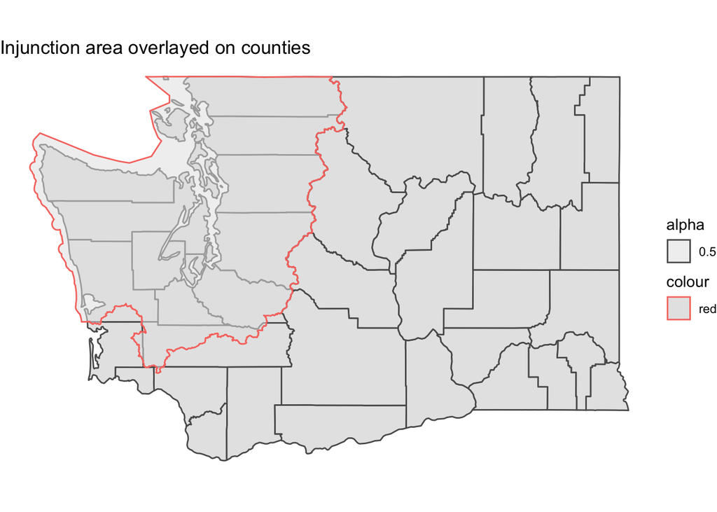

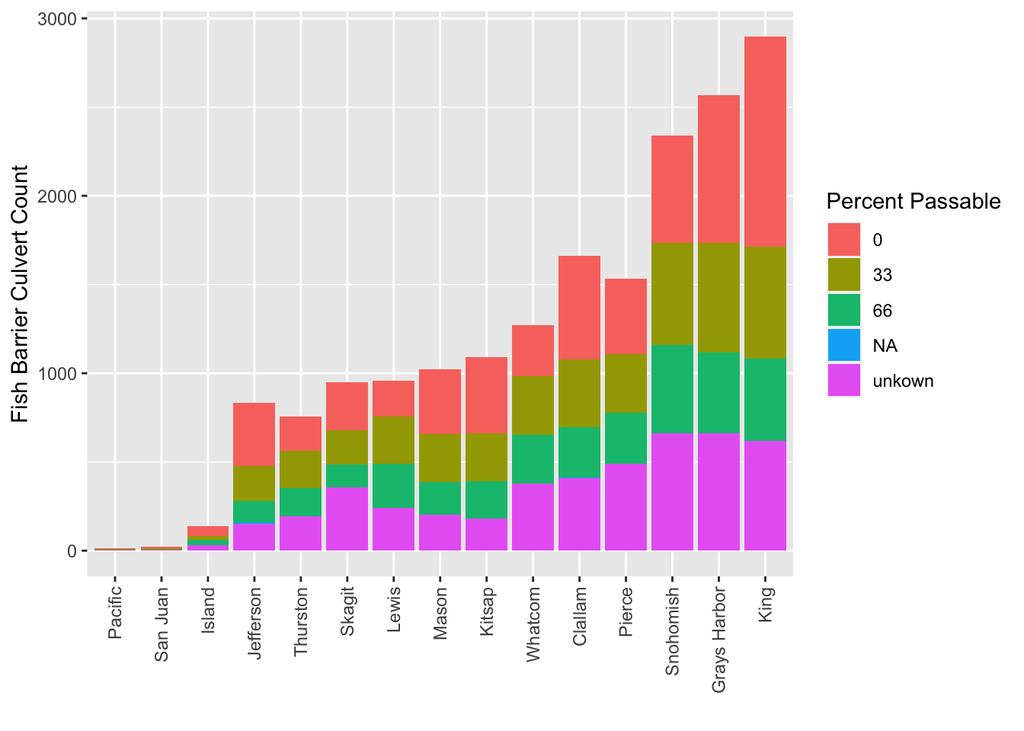

## Injunction Area Fish Barrier Culverts Priority Index Scores

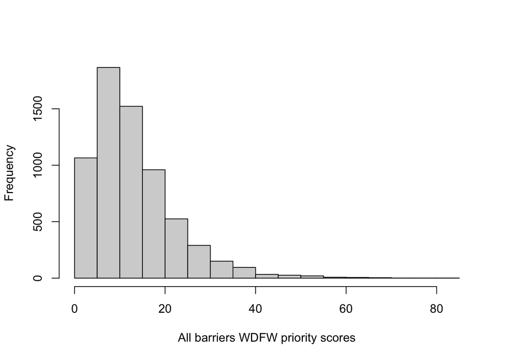

```r
# Hist of WDFW Scores, whole data set and injunction area

hist(sf_allculv_wdfw$priority_index_total_quantity,
     main = "",
     xlab = "All barriers WDFW priority scores")
```

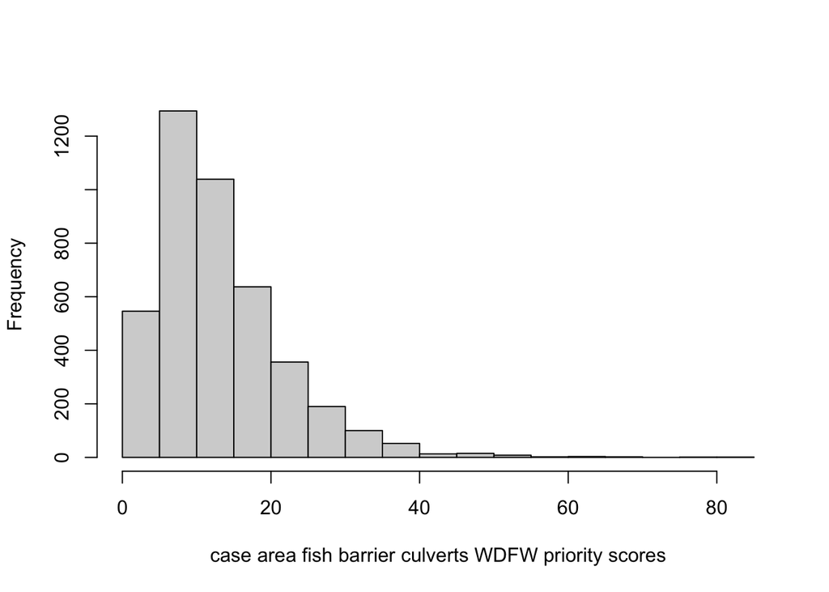

```r
hist(sf_case_culverts$priority_index_total_quantity,
     main = "",
     xlab = "case area fish barrier culverts WDFW priority scores")
```

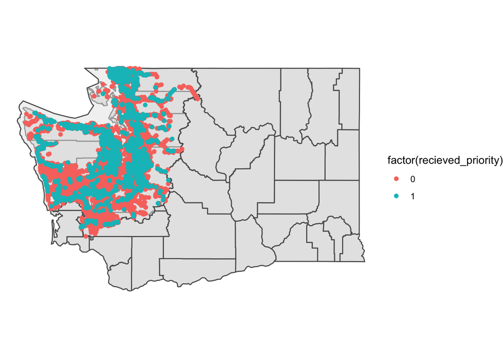

```r
# Plot PI scored and un-scored culverts
whole.count = sf_case_culverts %>%
  mutate(culvert_count = n())

whole.count$recieved_priority = ifelse(is.na(whole.count$priority_index_total_quantity), 0, 1)

whole.count =whole.count %>%
  mutate(percent_scored = mean(recieved_priority))

priotizied = whole.count %>%
  filter(recieved_priority == 1)

wa.plot.case <- ggplot() +
  geom_sf(data = counties) +
  geom_sf(data = sf_case,
          alpha = .5) +
  geom_sf(data = whole.count, aes(color = factor(recieved_priority))) +
  theme_void()
wa.plot.case
```

## Injunction Area Fish Barrier Culverts (Median Survey Age by County)

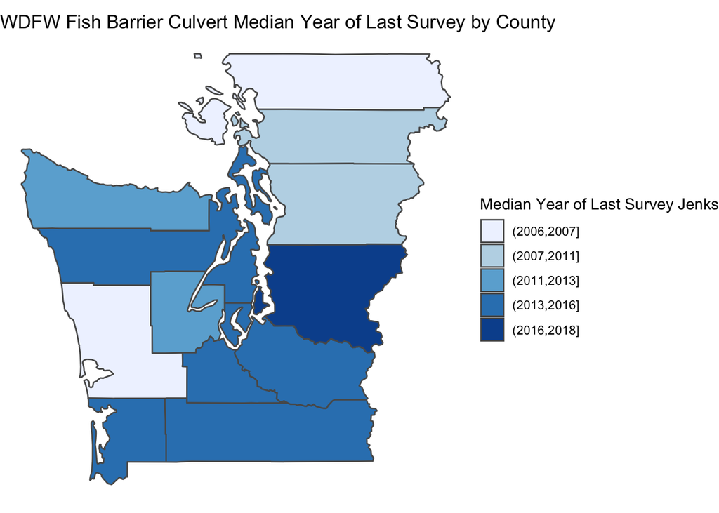

## Culvert Count and Road Miles Comparison along with PI percentage

Here we explore the count of fish barrier culverts by county and it is related to road miles. Centerline road miles per county was pulled from WSDOT at (https://www.wsdot.wa.gov/mapsdata/travel/hpms/annualmileage.htm). The code provides a template for comparing culvert count with other county level variables of interest. The code also contains how to extract the percentage of the culverts by county that have a PI score compared to those that do not in the WDFW data set. As you can see, a majority of culverts do not have PI scores.

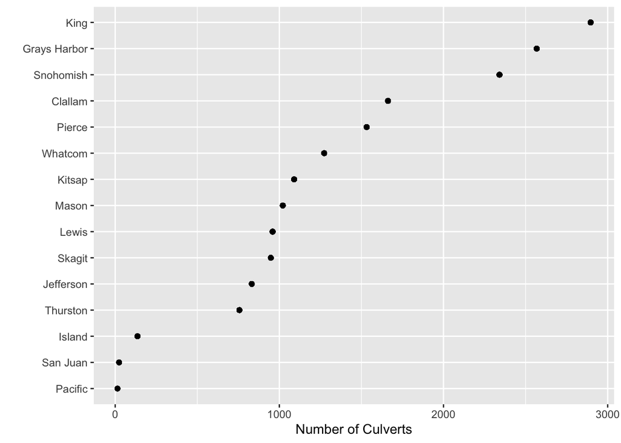

```r
# Get culvert count
sf_case_culverts.count = sf_case_culverts %>%
  group_by(county_name) %>%
  mutate(culvert_count = n())

# Plot culvert count
ggplot(sf_case_culverts.count, aes(x = reorder(county_name, culvert_count), y = culvert_count)) +
  geom_point()  +
  coord_flip() +
  ylab("Number of Culverts") +
  xlab("")
```

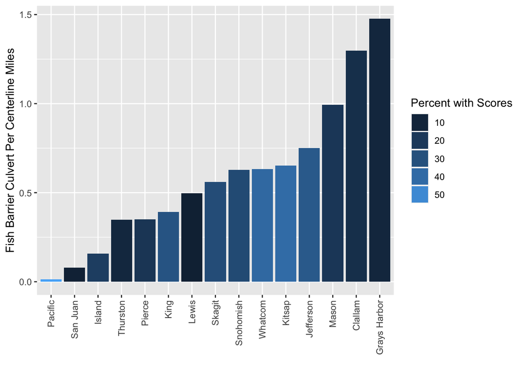

```r
# Get percentage of culverts with PI score by county
sf_case_culverts.count$recieved_priority = ifelse(is.na(sf_case_culverts.count$priority_index_total_quantity), 0, 1)

sf_case_culverts.count = sf_case_culverts.count %>%
  group_by(county_name) %>%
  mutate(percent_scored = mean(recieved_priority)*100)

# Load county centerline miles
centerline_miles <- read_excel(here("data", "DVMT2020COrpt.xlsx"),
                    sheet = "centerline_miles")

sf_case_culverts.count = sf_case_culverts.count %>%
  merge(centerline_miles)

culvert_by_milage = sf_case_culverts.count %>%
  select(c(county_name, culvert_count, centerline_miles, percent_scored)) %>%
  st_drop_geometry() %>%
  unique() %>%
  mutate(barrier_per_mile = culvert_count / centerline_miles)

# Create plot showing culvert per mile and percent with scores per county
ggplot(culvert_by_milage, aes(fill = percent_scored,
                              y = barrier_per_mile, x = reorder(county_name, barrier_per_mile))) +
  geom_bar(position="stack", stat="identity") +
  xlab("") +
  ylab("Fish Barrier Culvert Per Centerline Miles") +
  guides(fill=guide_legend(title= "Percent with Scores")) +
  theme(axis.text.x = element_text(angle = 90, vjust = 0.5, hjust=1))
```

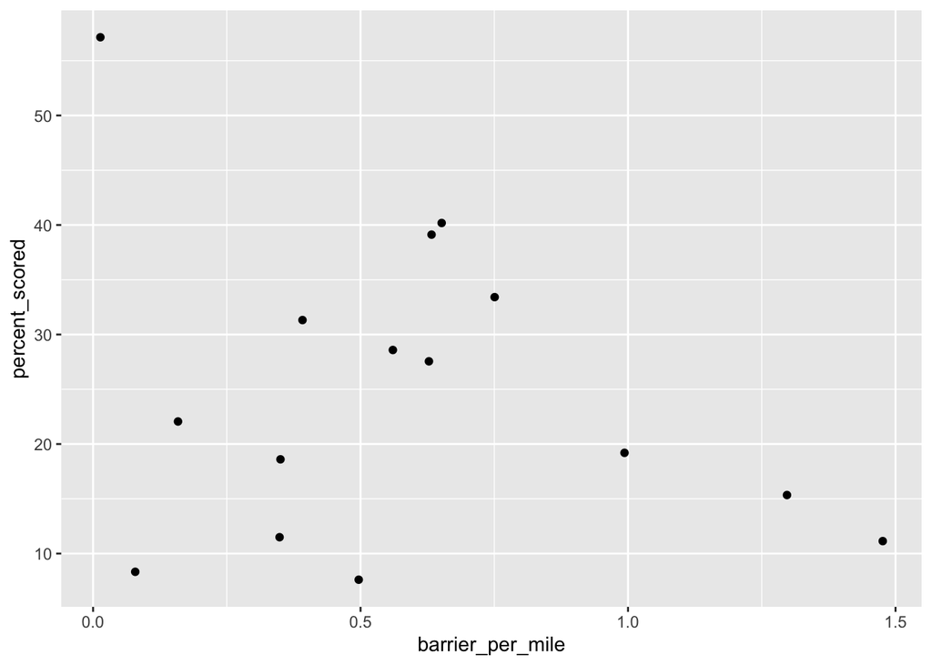

```r
# Explore relationship between percent of culverts with score and road miles
ggplot(culvert_by_milage, aes(x = barrier_per_mile, y = percent_scored)) +
  geom_point()
```

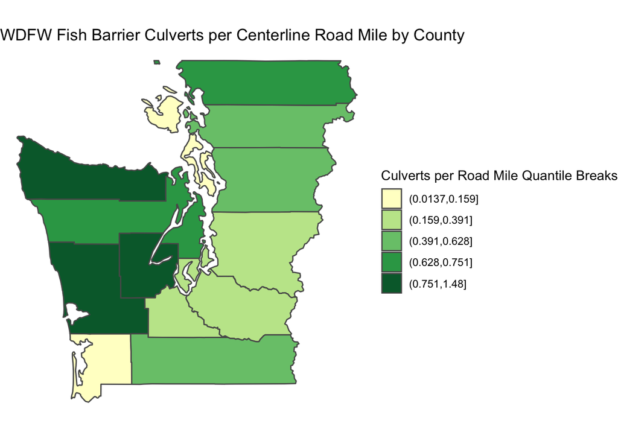

```r
# Map Fish Barrier Culvert by Mile per County
counties <- read_sf(here("data", "cb_2018_us_county_5m", "cb_2018_us_county_5m.shp"))
counties = counties %>%
  rename(county_name = NAME) %>%
  filter(STATEFP == "53")

counties <- subset(counties, county_name %in% culvert_by_milage$county_name)

culvert_by_milage =  counties %>%
  merge(culvert_by_milage)

# Fish Barrier Culverts per Road Mile breaks and map
breaks_qt <- classIntervals(c(min(culvert_by_milage$barrier_per_mile) - .00001, culvert_by_milage$barrier_per_mile), n = 5, style = "quantile")

culvert_by_milage <- mutate(culvert_by_milage, barrier_per_mile_cut = cut(barrier_per_mile, breaks_qt$brks))

ggplot(culvert_by_milage) +
  geom_sf(aes(fill =  barrier_per_mile_cut)) +
  scale_fill_brewer(palette = "YlGn") +
  theme_void() +
  guides(fill=guide_legend(title= "Culverts per Road Mile Quantile Breaks")) +
  labs(title = "WDFW Fish Barrier Culverts per Centerline Road Mile by County")
```

## Gini Coefficient and Standard Dev. of Prioritization Scores by County

Here we explore the PI scores in this data set a bit further. The below code looks at the prioritization scores from the WDFW data set in terms of the Gini coefficient and the standard dev. The Gini coefficients are plotted by county and this, along with standard deviation of the PI, is then displayed in a table as well as on a map using Jenks breaks.

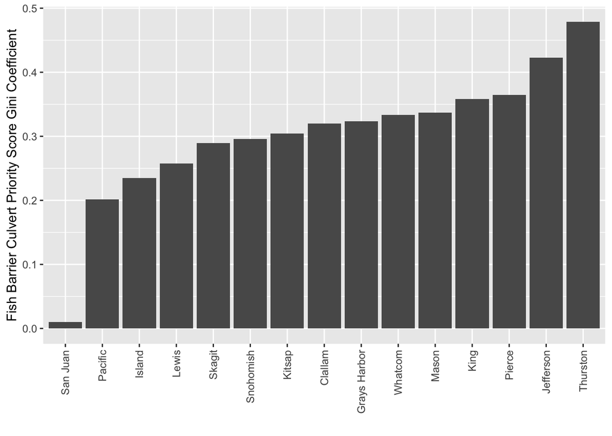

```
##          County PI Score Standard Dev. PI Score Gini Coefficient
## 1         Lewis              4.6692911                0.25755542
## 2       Pacific              2.7801016                0.20169970
## 3        Pierce             10.6745393                0.36464034
## 4      Thurston             10.8433761                0.47851578
## 5  Grays Harbor              7.5188764                0.32357720
## 6         Mason              7.2995183                0.33715727
## 7          King              8.9159079                0.35839497
## 8        Kitsap              8.5265383                0.30428038
## 9     Jefferson             11.6025047                0.42269275
## 10    Snohomish              8.0106461                0.29592480
## 11      Clallam              7.2867979                0.32000851
## 12       Island              4.6133463                0.23499974
## 13       Skagit              6.0832191                0.28969798
## 14     San Juan              0.1131373                0.01017814
## 15      Whatcom              7.7891742                0.33333683
```

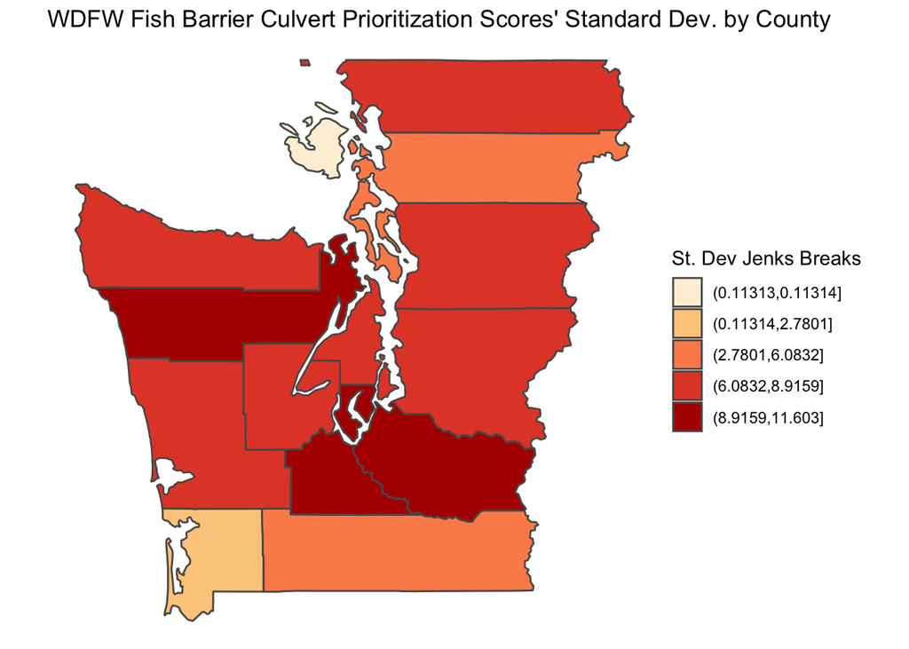

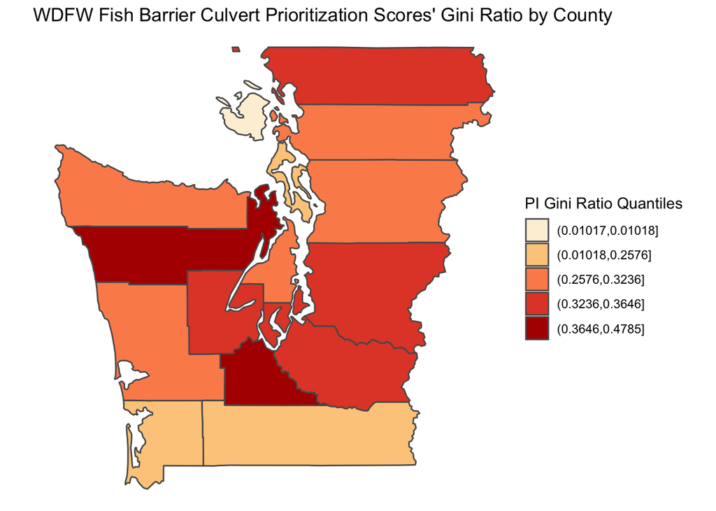